# Shiva_Neelakantan_HW8.Rmd

Shiva Neelakantan

2022-04-05

# Problem 1: Bootstrap

## 1a

```r
library(ISLR2)
```

```r
beta0_star = summary(lm(medv~crim+age,data=Boston))$coef[1,1]
se_b0_star = summary(lm(medv~crim+age,data=Boston))$coef[1,2]
n = dim(Boston)[1]
B = 500
m = 100
Fstar = rep(0,B)
beta0_m = rep(0,m)

for(b in 1:B){
  index = sample(1:n,n,replace=TRUE)
  bootsample=Boston[index,]
  fit = lm(medv~crim+age,data=bootsample)
  beta0 =  coef(fit)[1]
  for(i in 1:m){
    index2 = sample(index,n,replace=TRUE)
    bootsample2 = Boston[index2,]
    fit2 = lm(medv~crim+age,data=bootsample2)
    beta0_m[i] = coef(fit2)[1]
  }
  se_b0 = sqrt(sum((beta0_m-mean(beta0_m))^2)/(m-1))

  Fstar[b] = (beta0 - beta0_star)/se_b0
}
```

```r
#95% confidence interval
beta0_star + quantile(Fstar,0.025)*se_b0_star
```

```
##     2.5%
## 27.82368
```

```r
beta0_star + quantile(Fstar,0.975)*se_b0_star
```

```
##    97.5%
## 31.48186
```

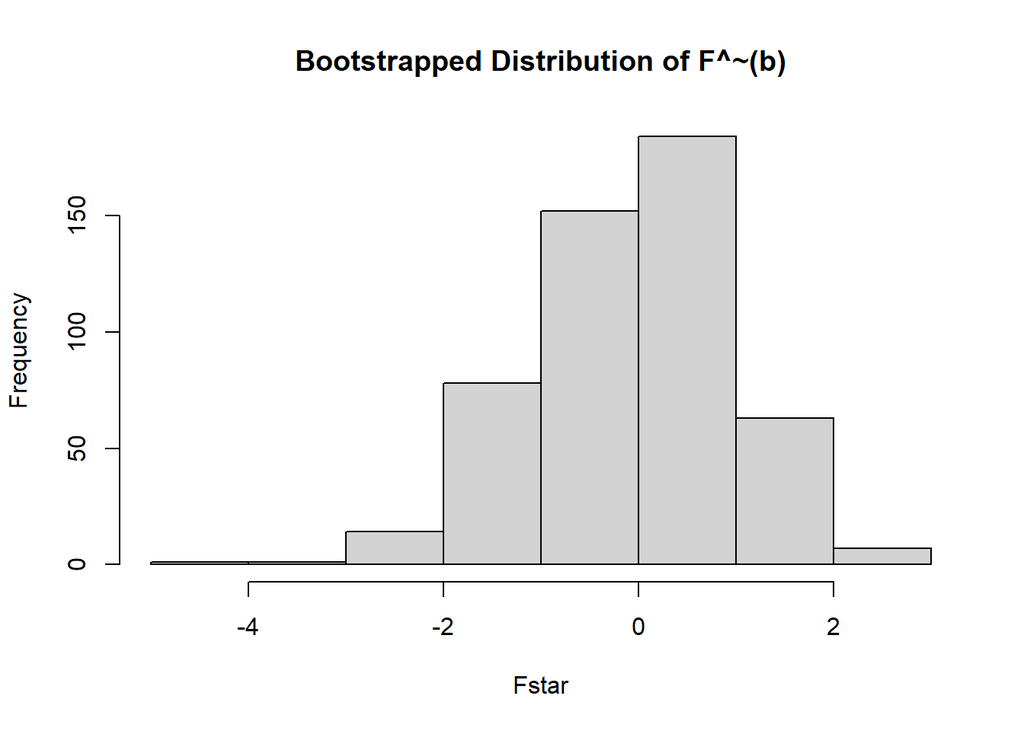

```r
#bootstrapped distribution
hist(Fstar, main='Bootstrapped Distribution of F^~(b)')
```

## 1b

```r
confint(lm(medv~crim+age,data=Boston))
```

```
##                  2.5 %      97.5 %
## (Intercept) 27.8933870 31.70794700
## crim        -0.4004172 -0.22321431
## age         -0.1166275 -0.06247902
```

The 95% CI obtained by boostrapping is slightly narrower than the one obtained from the analytical formula; nonetheless, they are still very similar in their range of values.

## 1c

```r
medv.median = median(Boston$medv, na.rm=TRUE)
medv.median
```

```
## [1] 21.2
```

## 1d

```r
B = 2000
median_boot = rep(0,2000)
for(b in 1:B){
  index = sample(1:n,n,replace=TRUE)
  bootsample = Boston[index,]
  median_boot[b] = median(bootsample$medv, na.rm=TRUE)
}
medSE = sqrt(sum((median_boot-mean(median_boot))^2)/(B-1))
medSE
```

```
## [1] 0.3810323
```

## 1e

```r
med.star = median(Boston$medv, na.rm=TRUE)
se.med.star = medSE

B = 1000
m = 100
n = dim(Boston)[1]
Fstar = rep(0, B)
med_m = rep(0, m)

for(b in 1:B){
  index = sample(1:n, n, replace=TRUE)
  bsample1 = Boston[index, ]
  med = median(bsample1$medv, na.rm=TRUE)

  for(i in 1:m){
    index2 = sample(index, n, replace=TRUE)
    bsample2 = Boston[index2, ]
    med_m[i] = median(bsample2$medv, na.rm=TRUE)
  }

  se_med = sqrt(sum((med_m - mean(med_m))^2)/(m-1))
  Fstar[b] = (med - med.star)/se_med
}
```

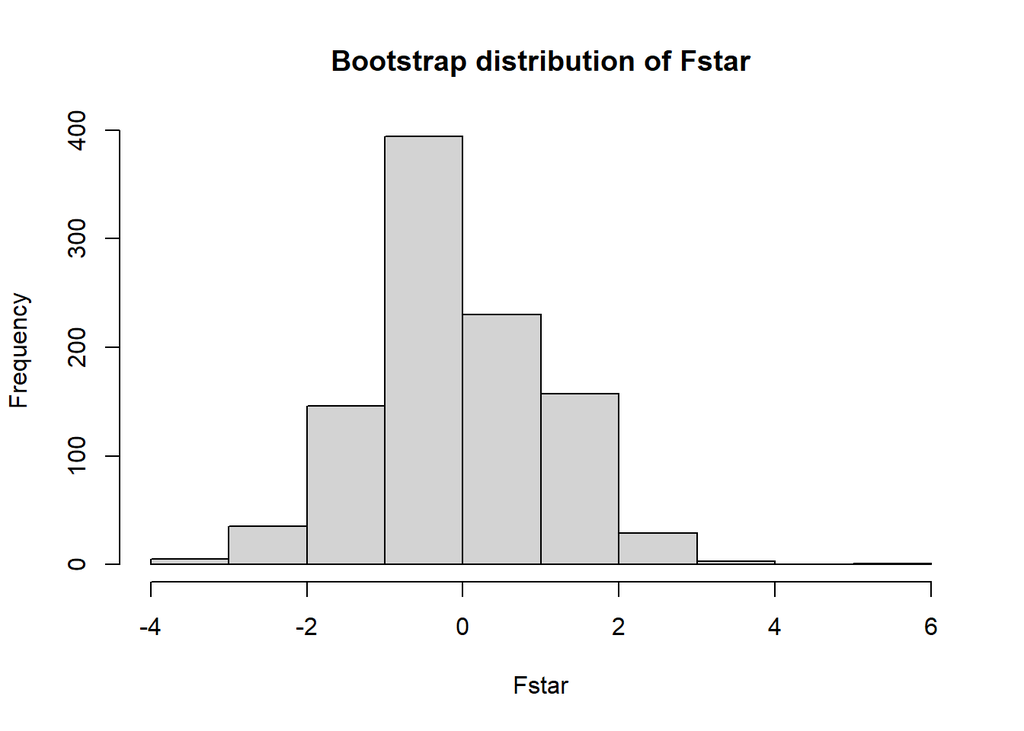

```r
hist(Fstar, main='Bootstrap distribution of Fstar')
```

```r
med.star + quantile(Fstar, 0.025)*se.med.star
```

```
##     2.5%
## 20.36943
```

```r
med.star + quantile(Fstar, 0.975)*se.med.star
```

```
##    97.5%
## 22.05682
```

## 1f

```r
quantile(Boston$medv, 0.10)
```

```
##   10%
## 12.75
```

## 1g

```r
B = 1000
m = 100
n = dim(Boston)[1]

mu_10_arr = rep(0, m)
se_arr = rep(0, B)

for (b in 1:B) {
  idx = sample(1:n, n, replace=TRUE)
  bootsample = Boston[idx, ]
  mu_10 = quantile(bootsample$medv, 0.10)
  for (i in 1:m) {
    idx2 = sample(idx, n, replace=TRUE)
    bootsample2 = Boston[idx2, ]
    mu_10_v2 = quantile(bootsample2$medv, 0.10)
    mu_10_arr[i] = mu_10_v2
  }
  se_mu = sqrt(sum((mu_10_arr - mean(mu_10_arr))^2)/(m-1))
  se_arr[b] = (mu_10-(quantile(Boston$medv, 0.10)))/se_mu
}
mean(se_arr)
```

```
## [1] 0.1731202
```

# Problem 2: Email Spam

```r
spam = read.csv('C:/Users/shivn/Downloads/spambase.data', header=FALSE)
```

## 2a

```r
library(dplyr)
df = spam %>% count(V58)
proportion = df[[2]][[2]]/nrow(spam)
proportion
```

```
## [1] 0.3940448
```

## 2b

```r
n = nrow(spam)
train = sample(1:n, n/2, replace=FALSE)
test = -train
df.train = spam[train, ]
df.test = spam[-train, ]

train.proportion = (df.train %>% count(V58))[[2]][[2]] / (n/2)
train.proportion
```

```
## [1] 0.3725277
```

```r
test.proportion = (df.test %>% count(V58))[[2]][[2]] / (n/2)
test.proportion
```

```
## [1] 0.4155618
```

## 2c

```r
glm.fit = glm(V58~., data=spam, subset=train, family='binomial')
glm.prob = predict(glm.fit, spam[test, ], type='response')
head(glm.prob, 10)
```

```
##         1         3         4         6         8         9        10        12
## 0.5958057 0.9999997 0.8745446 0.9165671 0.9158136 0.9999998 0.9071528 0.5086371
##        14        15
## 0.7821550 0.9988336
```

```r
head(spam[test, ], 10)$V58
```

```
##  [1] 1 1 1 1 1 1 1 1 1 1
```

## 2d

```r
glm.pred = rep(1, length(test))
glm.pred[glm.prob <= 0.5] = 0
conf.matrix = table(glm.pred, spam[test, ]$V58)
conf.matrix # rows are preds, cols are actual
```

```
##
## glm.pred    0    1
##        0 1276  107
##        1   69  849
```

```r
misclassification.rate = 1 - mean(glm.pred == spam[test, ]$V58)
misclassification.rate
```

```
## [1] 0.07648848
```

```r
false.neg.rate = conf.matrix[1,2] / length(test)
false.neg.rate
```

```
## [1] 0.04652174
```

```r
false.pos.rate = conf.matrix[2,1] / length(test)
false.pos.rate
```

```
## [1] 0.03
```

## 2e

Reporting a meaningful email as spam is a more egregious mistake in my opinion, because I have had situations where I never saw a very important email from a recruiter or other professional for more than a month due to it being marked as spam.

To accommodate this, we would want to raise the classifier’s activation threshold for what it classifies as spam. Right now, it only needs to be greater than 0.5 to be considered a spam email. If we raise this activation to say, 0.7, then the classifier is less likely to report as many emails as spam, because it will require a higher probability to consider the email to be spam.

# Problem 3: Weekly data set

## 3a

```r
head(Weekly)
```

```
##   Year   Lag1   Lag2   Lag3   Lag4   Lag5    Volume  Today Direction
## 1 1990  0.816  1.572 -3.936 -0.229 -3.484 0.1549760 -0.270      Down
## 2 1990 -0.270  0.816  1.572 -3.936 -0.229 0.1485740 -2.576      Down
## 3 1990 -2.576 -0.270  0.816  1.572 -3.936 0.1598375  3.514        Up
## 4 1990  3.514 -2.576 -0.270  0.816  1.572 0.1616300  0.712        Up
## 5 1990  0.712  3.514 -2.576 -0.270  0.816 0.1537280  1.178        Up
## 6 1990  1.178  0.712  3.514 -2.576 -0.270 0.1544440 -1.372      Down
```

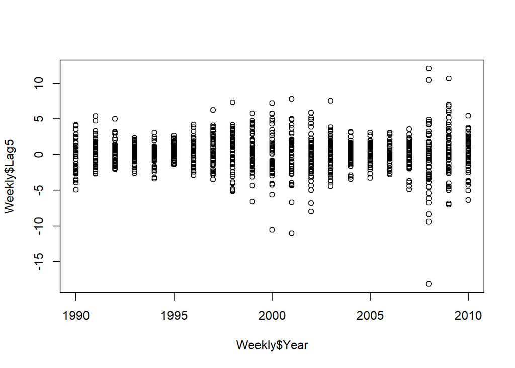

```r
plot(Weekly$Year, Weekly$Lag5)
```

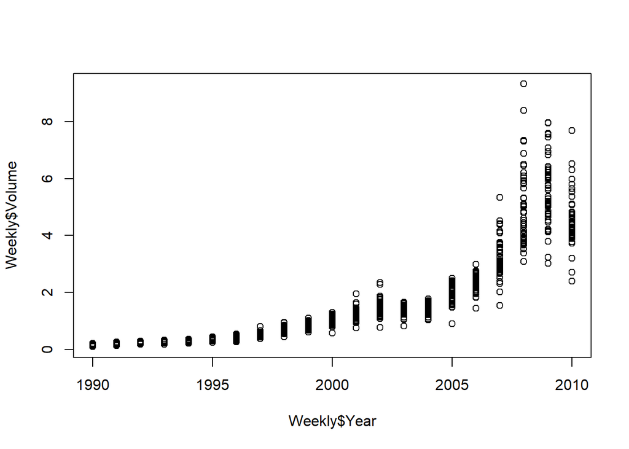

```r
plot(Weekly$Year, Weekly$Volume)
```

The percentage return columns (Lag1 through Lag5) show pretty similar patterns across time. The volume of shares traded grew exponentially up til 2008, and then started falling off. This is probably attributed to the 2008 recession.

## 3b

```r
logreg = glm(Direction~Lag1+Lag2+Lag3+Lag4+Lag5+Volume, data=Weekly, family='binomial')
summary(logreg)
```

```
##
## Call:
## glm(formula = Direction ~ Lag1 + Lag2 + Lag3 + Lag4 + Lag5 +
##     Volume, family = "binomial", data = Weekly)
##
## Deviance Residuals:
##     Min       1Q   Median       3Q      Max
## -1.6949  -1.2565   0.9913   1.0849   1.4579
##
## Coefficients:
##             Estimate Std. Error z value Pr(>|z|)
## (Intercept)  0.26686    0.08593   3.106   0.0019 **
## Lag1        -0.04127    0.02641  -1.563   0.1181
## Lag2         0.05844    0.02686   2.175   0.0296 *
## Lag3        -0.01606    0.02666  -0.602   0.5469
## Lag4        -0.02779    0.02646  -1.050   0.2937
## Lag5        -0.01447    0.02638  -0.549   0.5833
## Volume      -0.02274    0.03690  -0.616   0.5377
## ---
## Signif. codes:  0 '***' 0.001 '**' 0.01 '*' 0.05 '.' 0.1 ' ' 1
##
## (Dispersion parameter for binomial family taken to be 1)
##
##     Null deviance: 1496.2  on 1088  degrees of freedom
## Residual deviance: 1486.4  on 1082  degrees of freedom
## AIC: 1500.4
##
## Number of Fisher Scoring iterations: 4
```

The Lag2 coefficient appears to be the most significant predictor (excluding beta0). This is due to its very low alpha value of 0.0296.

## 3c

```r
logregpred = predict(logreg, Weekly, type='response')
glm.pred = rep(1, nrow(Weekly))
glm.pred[logregpred <= 0.5] = 0
conf.matrix = table(glm.pred, Weekly$Direction)
conf.matrix
```

```
##
## glm.pred Down  Up
##        0   54  48
##        1  430 557
```

```r
false.neg.rate = conf.matrix[1,2] / nrow(Weekly)
false.neg.rate
```

```
## [1] 0.04407713
```

```r
false.pos.rate = conf.matrix[2,1] / nrow(Weekly)
false.pos.rate
```

```
## [1] 0.3948577
```

The false negative rate, or contextually, the rate at which the model believes the market should perform poorly but actually goes up, is very low, at 0.044. However, the false positive rate, or contextually, the rate at which the model believes the market should perform well but actually goes down, is surprisingly high, at 0.395. The model’s inaccuracy is strikingly similar to how humans tend to mistime the market – we hear more stories of people believing the market is going to boom, and then the opposite occurring, than we do of the inverse.

## 3d

```r
years.90.to.08 = Weekly %>% filter(Year >= 1990 & Year <= 2008)
years.09.and.10 = Weekly %>% filter(Year == 2009 | Year == 2010)

logreg.lag2 = glm(Direction~Lag2, data=years.90.to.08, family='binomial')
logregpred = predict(logreg.lag2, years.09.and.10, type='response')
glm.pred = rep(1, nrow(years.09.and.10))
glm.pred[logregpred <= 0.5] = 0
conf.matrix = table(glm.pred, years.09.and.10$Direction)
conf.matrix
```

```
##
## glm.pred Down Up
##        0    9  5
##        1   34 56
```

```r
pred.acc = (conf.matrix[1, 1] + conf.matrix[2, 2]) / nrow(years.09.and.10)
pred.acc
```

```
## [1] 0.625
```

# Problem 4: Limitations of Logistic Regression

## 4a

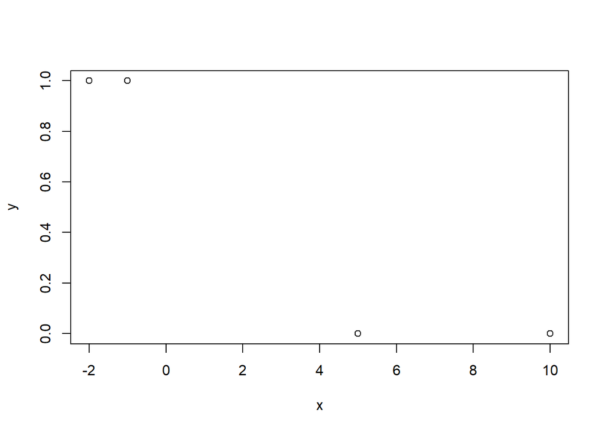

```r
x = c(-2, 5, -1, 10, 5)
red = 1
blue = 0
y = c(red, blue, red, blue, blue)
df = data.frame(x, y)
plot(x, y)
```

We observe what looks like a reversed sigmoid/logistic regression curve. The data does appear well separated, as the red values are at 1 and the blues are at 0.

## 4b

```r
limlogreg = glm(y~x, df, family='binomial')
```

```
## Warning: glm.fit: fitted probabilities numerically 0 or 1 occurred
```

```r
summary(limlogreg)
```

```
##
## Call:
## glm(formula = y ~ x, family = "binomial", data = df)
##
## Deviance Residuals:
##          1           2           3           4           5
##  2.110e-08  -1.164e-05   1.334e-05  -2.110e-08  -1.164e-05
##
## Coefficients:
##             Estimate Std. Error z value Pr(>|z|)
## (Intercept)    15.38   54271.11   0.000        1
## x              -7.76   13792.23  -0.001        1
##
## (Dispersion parameter for binomial family taken to be 1)
##
##     Null deviance: 6.7301e+00  on 4  degrees of freedom
## Residual deviance: 4.4882e-10  on 3  degrees of freedom
## AIC: 4
##
## Number of Fisher Scoring iterations: 23
```

We receive the following warning message: `Warning: glm.fit: fitted probabilities numerically 0 or 1 occurred`.

## 4c

According to the summary of our logistic regression model in part (4b), the coefficients we want to use to maximize the likelihood estimation of our model are b0 = 15.38 and b1 = -7.76.

## 4d

One limitation with the logistic regression model is that its precision is very low. We see this particularly from the standard errors reflected in the coeficients calculated by our model’s summary in part (4b).